# Analiza rozkładów stóp zwrotów wybranych spółek giełdowych

Olga Sieradzan, Aleksandra Węgrzyn

2024-01-09

## Wstęp

Dane wykorzystane w poniższym projekcie zostały pobrane ze strony [stooq.pl](https://stooq.pl/). Dane dotyczą notowań akcji spółki *AmRest Holdings* z indeksu WIG40 oraz notowań akcji spółki *CD PROJEKT* z indeksu WIG20 w latach 2022 - 2023.

## 1. Dzienne i tygodniowe logarytmiczne stopy zwrotu akcji

W poniższych tabelach zostały przedstawione dzienne i tygodniowe logarytmiczne stopy zwrotu akcji dla spółek: *AmRest Holdings* oraz *CD PROJEKT*.

Ze względu na dużą liczbę danych prezentujemy jedynie kilka początkowych wartości.

*Tabela 1.1. Tygodniowe logarytmiczne stopy zwrotu akcji spółki AmRest Holdings*

|  | Dzień | stopy zwrotu |
| --- | --- | --- |
| 1 | 2022-01-09 | 0.0382 |
| 2 | 2022-01-16 | -0.0411 |
| 3 | 2022-01-23 | -0.0339 |
| 4 | 2022-01-30 | -0.0641 |
| 5 | 2022-02-06 | 0.0827 |
| 6 | 2022-02-13 | 0.0168 |

*Wykres 1.1. Tygodniowe logarytmiczne stopy zwrotu akcji spółki AmRest Holdings*

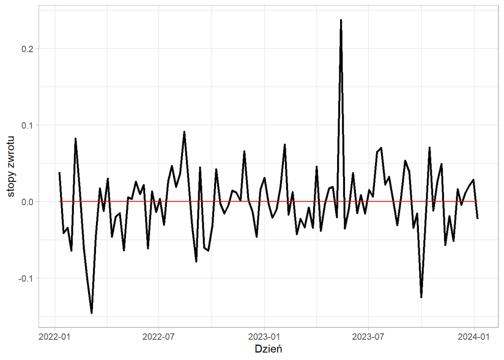

*Tabela 1.2. Dzienne logarytmiczne stopy zwrotu akcji spółki AmRest Holdings*

|  | Dzień | stopy zwrotu |
| --- | --- | --- |
| 1 | 2022-01-04 | 0.0277 |
| 2 | 2022-01-05 | -0.0127 |
| 3 | 2022-01-07 | 0.0203 |
| 4 | 2022-01-10 | -0.0239 |
| 5 | 2022-01-11 | 0.0000 |
| 6 | 2022-01-12 | -0.0079 |

*Wykres 1.2. Dzienne logarytmiczne stopy zwrotu akcji spółki AmRest Holdings*

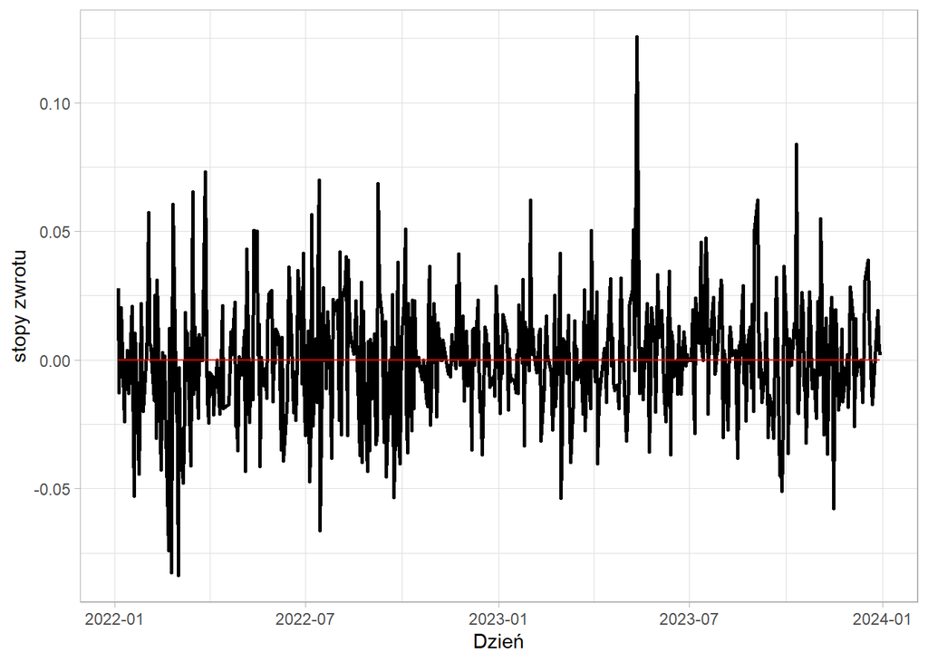

|  | Dzień | stopy zwrotu |
| --- | --- | --- |
| 1 | 2022-01-04 | -0.0107 |
| 2 | 2022-01-05 | 0.0275 |
| 3 | 2022-01-07 | -0.0266 |
| 4 | 2022-01-10 | -0.0545 |
| 5 | 2022-01-11 | 0.0024 |
| 6 | 2022-01-12 | 0.0387 |

*Wykres 1.3. Dzienne logarytmiczne stopy zwrotu akcji spółki CD PROJEKT*

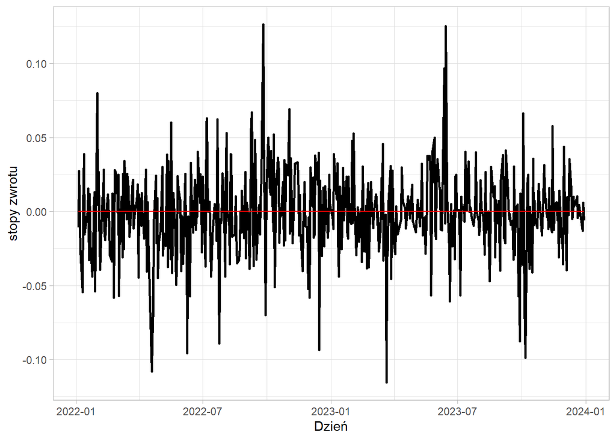

|  | Dzień | stopy zwrotu |
| --- | --- | --- |
| 1 | 2022-01-09 | 0.0293 |
| 2 | 2022-01-16 | -0.0392 |
| 3 | 2022-01-23 | -0.0265 |
| 4 | 2022-01-30 | -0.1124 |
| 5 | 2022-02-06 | 0.0678 |
| 6 | 2022-02-13 | 0.0008 |

*Wykres 1.4. Tygodniowe logarytmiczne stopy zwrotu akcji spółki CD PROJEKT*

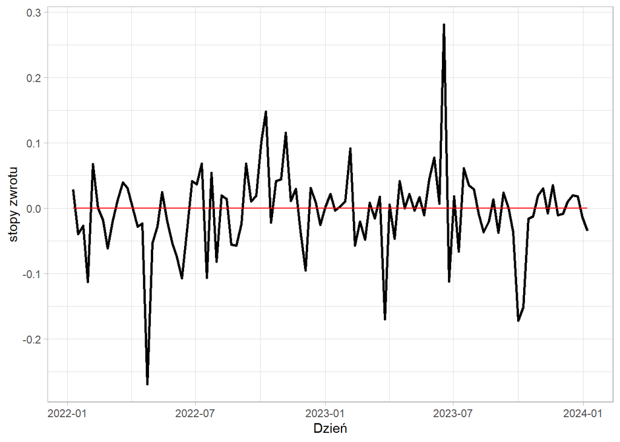

## 2. Statystyki opisowe oraz wizualizacje rozkładów

*Tabela 2.1. Podstawowe charakterystyki rozkładów stóp zwrotu akcji dla całości danych*

|  | Średnia | Odchylenie_standardowe | Skośność | Kurtoza |
| --- | --- | --- | --- | --- |
| AmRest tygodniowe | -0.0006 | 0.0477 | 0.7691 | 8.3632 |
| AmRest dzienne | -0.0001 | 0.0244 | 0.3471 | 4.9151 |
| CD Projekt tygodniowe | -0.0051 | 0.0658 | -0.1231 | 7.9579 |
| CD Projekt dzienne | -0.0011 | 0.0293 | -0.0787 | 5.3174 |

Analizując powyższą tabelę można zauważyć, że:

- Najniższa średnia stopa zwrotu akcji w badanym okresie dotyczyła spółki *CD PROJEKT* i wynosiła - 0.0051.
- Stopy zwrotu akcji spółki *AmRest Holdings* charakteryzuje asymetria prawostronna. Zatem większość stóp zwrotu akcji ma wartość poniżej średniej wartości. Z kolei stopy zwrotu akcji spółki *CD PROJEKT* cechuje asymetria lewostronna, wskazująca na większą część stóp zwrotu akcji mieszczących się powyżej średniej wartości.
- Najwyższą wartość odchylenia standardowego osiągnęły tygodniowe notowania akcji spółki *CD PROJEKT* - 0.0658. Oznacza to, iż dane te charakteryzuje największe zróżnicowanie.
- Najwyższa kurtoza stóp zwrotu akcji odnosi się do danych tygodniowych i przyjmuje wartości bliskie 8 wskazujące na rozkład leptokurtyczny. Oznacza to większe skupienie wartości wokół średniej.

*Tabela 2.2. Podstawowe charakterystyki rozkładów stóp zwrotu akcji dla próbek*

|  | Średnia | Odchylenie_standardowe | Skośność | Kurtoza |
| --- | --- | --- | --- | --- |
| AmRest tygodniowe | -0.0057 | 0.2685 | 0.1277 | 1.9231 |
| AmRest dzienne | -0.0006 | 0.2421 | 0.0726 | 2.1979 |
| CD Projekt tygodniowe | -0.0044 | 0.3215 | -0.1120 | 2.3661 |
| CD Projekt dzienne | 0.0005 | 0.3156 | 0.1262 | 2.5015 |

Analizując powyższą tabelę można zauważyć, że:

### Wykresy pudełkowe

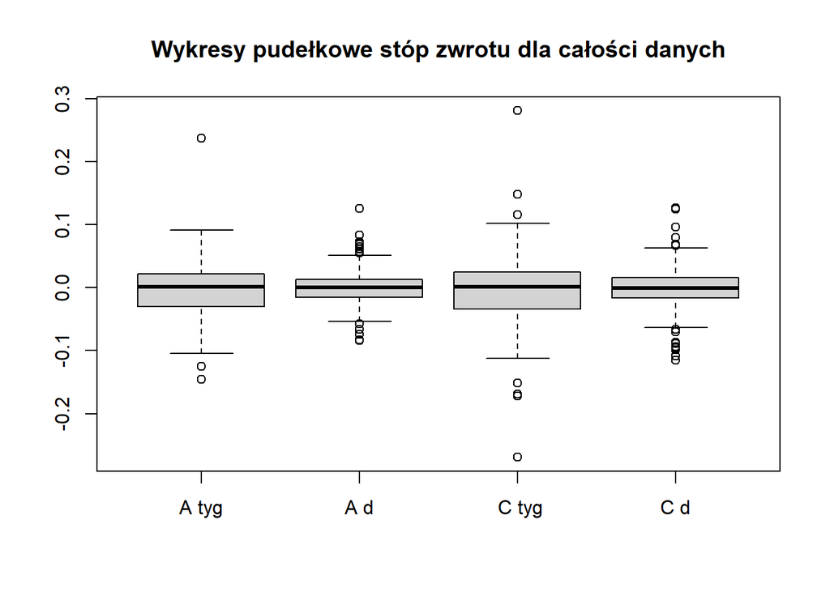

A dla przedsiebiorstwa *AmRest Holdings* oraz C dla przedsiębiorstwa *CD PROJEKT*. Literka *d* oznacza odczyty dzienne a, *tyg* oznacza odczyty tygodniowe. Z powyższych wykresów można zauważyć, że tygodniowe stopy zwrotu akcji charakteryzują się większym zróżnicowaniem w porównaniu do wartosci wyznaczonych na podstawie danych dziennych. Wyraźnie widoczna jest również różnica w asymetrii rozkładów. W przypadku stóp zwrotu akcji wyznaczonych na podstawie danych tygodniowych skośność jest większa.

Należy podkreślić, że w przypadku danych dziennych widoczne są liczne wartości odstające, które w znaczącym stopniu mogą zaburzać interpretację wyniku.

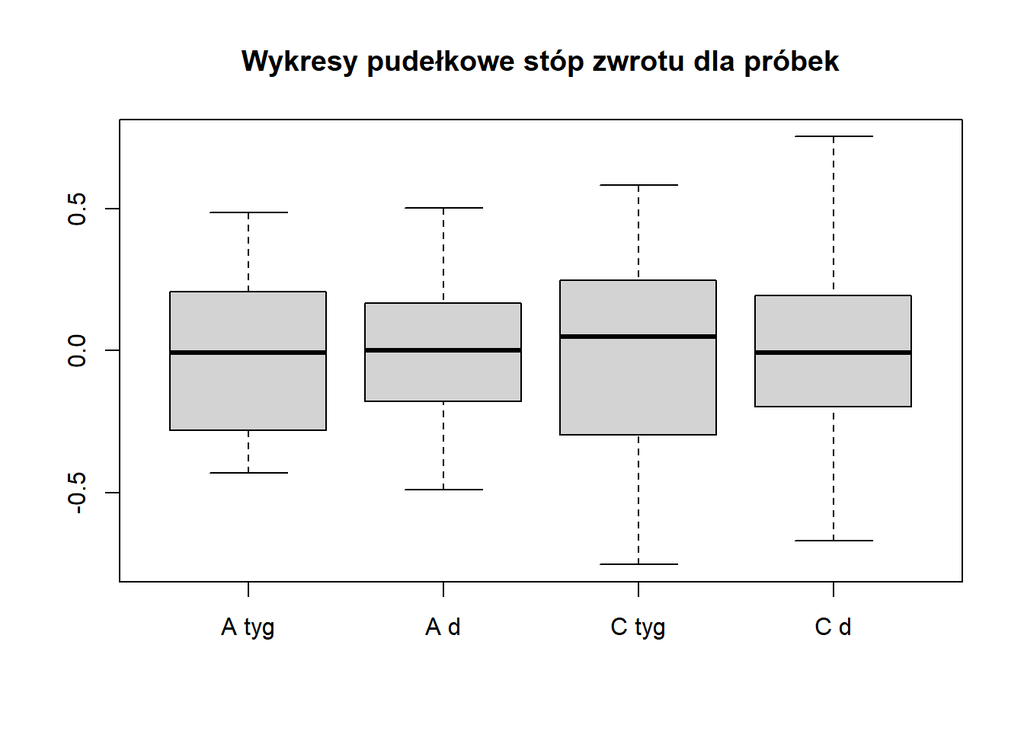

Analizując powyższe wykresy można wyciągnąć analogiczne wnioski jak w przypadku wizualizacji dla całości badanych danych. Rozkłady dla próbek dotyczących danych tygodniowych charakteryzują się większym zróżnicowaniem oraz asymetrią w porównaniu do danych dziennych. Jednakże ze względu na zmniejszenie liczebności danych, rozstęp międzykwartylowy jest znacznie szerszy niż ma to miejsce w przypadku badania całości danych.

### Wykresy gęstości

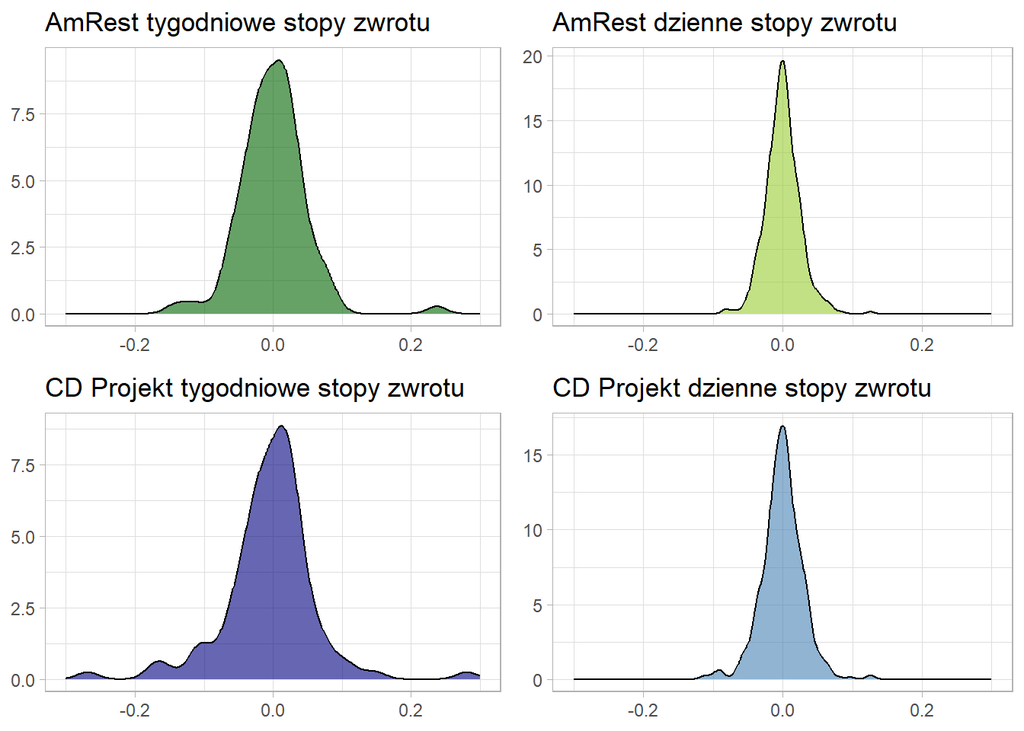

Na powyższych wizualizacjach jednoznacznie można dostrzec skupianie się wartosci wokół 0. Dodatkowo dla dziennych stóp zwrotu krzywa gestości jest bardziej “wysmukła” w porównaniu do tygodniowych.

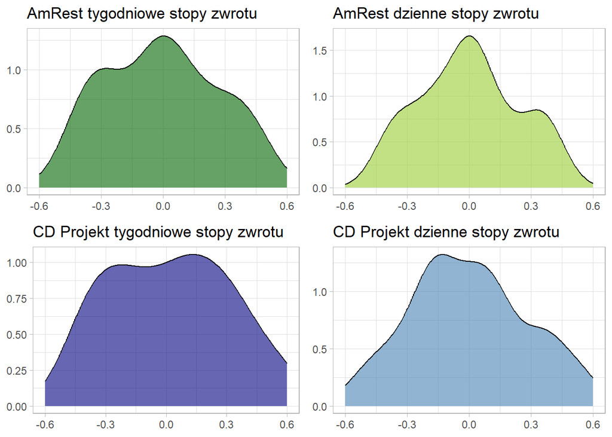

Z wykresów próbek cięzko wyciagnąć wnioski na temat rozkładów z jakich pochodzą, poniewaz wychodzi na to że wartości zostały wylosowane “po równo” , nie dając jasnego obrazu na to które sa najczęstsze a które są najżadsze.

## 3. Badanie zgodności rozkładu dziennych i tygodniowych stóp zwrotu z rozkładem normalnym

### Badanie danych całościowych

#### Test chi-kwadrat

Za pomocą testu chi-kwadrat dokonamy weryfikacji hipotezy o normalności badanego przez nas rozkładu.

**Hipoteza 0: Badany rozkład jest normalny**

**Hipoteza 1: Badany rozkład nie jest normalny**

poziom istotności α = 0.1

W poniższej tabeli prezentujemy zestawienie wartości p-value dla badanych rozkładów.

*Tabela 3.1. Wartości p-value dla badanych rozkładów wyznaczone za pomocą testu chi-kwadrat*

|  | test Chi-kwadrat |
| --- | --- |
| AmRest tygodniowe stopy zwrotu | 0.41988 |
| AmRest dzienne stopy zwrotu | 0.02112 |
| CD Projekt tygodniowe stopy zwrotu | 0.00966 |
| CD Projekt dzienne stopy zwrotu | 0.00967 |

Jedynie dla rozkładu tygodniowych stóp zwrotu spółki *AmRest Holdings* wartość p-value jest większa od przyjętego poziomu istotności α. W tym przypadku zgodnie z testem chi-kwadrat nie ma podstaw do odrzucenia hipotezy zerowej o zgodności badanego rozkładu z rozkładem normalnym.

Pozostałe wartości mieszczą się poniżej wartości 0.1, co oznacza odrzucenie hipotezy H0. Zatem na podstawie testu chi-kwadrat badane rozkłady nie mają rozkładu normalnego.

#### Test Kołmogorowa

Za pomocą testu Kołmogorowa dokonamy weryfikacji hipotezy o normalności badanego przez nas rozkładu.

**Hipoteza 0: Badany rozkład jest normalny**

**Hipoteza 1: Badany rozkład nie jest normalny**

poziom istotności α = 0.1

W poniższej tabeli prezentujemy zestawienie wartości p-value dla badanych rozkładów.

*Tabela 3.2. Wartości p-value dla badanych rozkładów wyznaczone za pomocą testu Kołmogorowa*

|  | test Kołmogorowa |
| --- | --- |
| AmRest tygodniowe stopy zwrotu | 0.69705 |
| AmRest dzienne stopy zwrotu | 0.14765 |
| CD Projekt tygodniowe stopy zwrotu | 0.09719 |
| CD Projekt dzienne stopy zwrotu | 0.05960 |

Dla rozkładów stóp zwrotu odnoszących się do spółki *AmRest Holdings* wartości p-value są większe od przyjętego poziomu istotności α. W ich przypadku nie ma podstaw do odrzucenia H0, co wskazuje na zgodność badanego rozkładu z rozkładem normalnym.

W przypadku rozkładów stóp zwrotu spółki *CD Projekt* wartości p-value są mniejsze od przyjętego poziomu istotności, zatem odrzucamy hipotezę główną. Oznacza to, że badane rozkłady nie są zgodne z rozkładem normalnym.

#### Test Shapiro - Wilka

Za pomocą testu Shapiro - Wilka dokonamy weryfikacji hipotezy o normalności badanego przez nas rozkładu.

**Hipoteza 0: Badany rozkład jest normalny**

**Hipoteza 1: Badany rozkład nie jest normalny**

poziom istotności α = 0.1

*Tabela 3.3. Wartości p-value dla badanych rozkładów wyznaczone za pomocą testu Shapiro-Wilka*

|  | test Shapiro-Wilka |
| --- | --- |
| AmRest tygodniowe stopy zwrotu | 3e-05 |
| AmRest dzienne stopy zwrotu | 0e+00 |
| CD Projekt tygodniowe stopy zwrotu | 0e+00 |
| CD Projekt dzienne stopy zwrotu | 0e+00 |

Dla wszystkich przypadków mieszczących się powyżej przyjętego poziomu istotności α, nie ma podstaw do odrzucenia H0. Analizując powyższą tabelę można zauważyć, iż wszystkie wyniki przeprowadzonego testu są znacznie mniejsze od tej wartości - R korzysta w tym celu z notacji wykładniczej. Zatem dla wszystkich badanych przypadków odrzucamy hipotezę główną.

Można zatem stwierdzić, iż na podstawie testu Shapiro - Wilka dane pochodzące z badanych rozkładów nie mają rozkładu normalnego.

#### Podsumowanie

W poniższej tabeli dokonałyśmy zestawienia wyników wartości p-value z trzech przeprowadzonych wcześniej testów.

*Tabela 3.4. Zestawienie wyników testów badających zgodność z rozkładem normalnym*

|  | Shapiro-Wilka | Kołmogorowa | Chi_kwadrat |
| --- | --- | --- | --- |
| AmRest tygodniowe stopy zwrotu | 3e-05 | 0.69705 | 0.41988 |
| AmRest dzienne stopy zwrotu | 0e+00 | 0.14765 | 0.02112 |
| CD Projekt tygodniowe stopy zwrotu | 0e+00 | 0.09719 | 0.00966 |
| CD Projekt dzienne stopy zwrotu | 0e+00 | 0.05960 | 0.00967 |

### Badanie próbek

#### Test chi-kwadrat

Za pomocą testu chi-kwadrat dokonamy weryfikacji hipotezy o normalności badanego przez nas rozkładu.

**Hipoteza 0: Badany rozkład jest normalny**

**Hipoteza 1: Badany rozkład nie jest normalny**

poziom istotności α = 0.1

W poniższej tabeli prezentujemy zestawienie wartości p-value dla badanych rozkładów.

*Tabela 3.5. Wartości p-value dla badanych rozkładów wyznaczone za pomocą testu chi-kwadrat*

|  | test Chi-kwadrat |
| --- | --- |
| AmRest tygodniowe stopy zwrotu | 0.49901 |
| AmRest dzienne stopy zwrotu | 0.07102 |
| CD Projekt tygodniowe stopy zwrotu | 0.61875 |
| CD Projekt dzienne stopy zwrotu | 0.61080 |

Jedynie dla rozkładu dziennych stóp zwrotu spółki *AmRest Holdings* wartość p-value jest mniejsza od przyjętego poziomu istotności α. W tym przypadku zgodnie z testem chi-kwadrat należy odrzucić hipotezę zerową o zgodności badanego rozkładu z rozkładem normalnym.

Pozostałe wartości mieszczą się powyżej wartości 0.1, co oznacza brak podstaw do odrzucenia hipotezy H0. Zatem na podstawie testu chi-kwadrat badane rozkłady mają rozkład normalny.

#### Test Kołmogorowa

Za pomocą testu Kołmogorowa dokonamy weryfikacji hipotezy o normalności badanego przez nas rozkładu.

**Hipoteza 0: Badany rozkład jest normalny**

**Hipoteza 1: Badany rozkład nie jest normalny**

poziom istotności α = 0.1

W poniższej tabeli prezentujemy zestawienie wartości p-value dla badanych rozkładów.

*Tabela 3.6. Wartości p-value dla badanych rozkładów wyznaczone za pomocą testu Kołmogorowa*

|  | test Kołmogorowa |
| --- | --- |
| AmRest tygodniowe stopy zwrotu | 0.74499 |
| AmRest dzienne stopy zwrotu | 0.56675 |
| CD Projekt tygodniowe stopy zwrotu | 0.92767 |
| CD Projekt dzienne stopy zwrotu | 0.75191 |

Dla wszystkich badanych rozkładów stóp zwrotu wartości p-value są większe od przyjętego poziomu istotności α. Nie ma więc podstaw do odrzucenia hipotezy H0, co wskazuje na zgodność badanych rozkładów z rozkładem normalnym.

#### Test Shapiro - Wilka

Za pomocą testu Shapiro - Wilka dokonamy weryfikacji hipotezy o normalności badanego przez nas rozkładu.

**Hipoteza 0: Badany rozkład jest normalny**

**Hipoteza 1: Badany rozkład nie jest normalny**

poziom istotności α = 0.1

*Tabela 3.7. Wartości p-value dla badanych rozkładów wyznaczone za pomocą testu Shapiro-Wilka*

|  | test Shapiro-Wilka |
| --- | --- |
| AmRest tygodniowe stopy zwrotu | 0.10624 |
| AmRest dzienne stopy zwrotu | 0.00694 |
| CD Projekt tygodniowe stopy zwrotu | 0.72063 |
| CD Projekt dzienne stopy zwrotu | 0.16450 |

Dla wszystkich przypadków mieszczących się powyżej przyjętego poziomu istotności α, nie ma podstaw do odrzucenia H0. Analizując powyższą tabelę można zauważyć, iż jedynie wartość p-value odnosząca się do dziennych stóp zwrotu spółki *AmRest Holdings* mieści się poniżej wartości 0.1, co wskazuje na odrzucenie hipotezy głównej.

Dla pozostałych badanych rozkładów można stwierdzić, iż na podstawie testu Shapiro - Wilka dane mają rozkład normalny.

#### Podsumowanie

W poniższej tabeli dokonałyśmy zestawienia wyników wartości p-value z trzech przeprowadzonych wcześniej testów.

*Tabela 3.8. Zestawienie wyników testów badających zgodność z rozkładem normalnym*

|  | Shapiro-Wilka | Kołmogorowa | Chi_kwadrat |
| --- | --- | --- | --- |
| AmRest tygodniowe stopy zwrotu | 0.10624 | 0.74499 | 0.49901 |
| AmRest dzienne stopy zwrotu | 0.00694 | 0.56675 | 0.07102 |
| CD Projekt tygodniowe stopy zwrotu | 0.72063 | 0.92767 | 0.61875 |
| CD Projekt dzienne stopy zwrotu | 0.16450 | 0.75191 | 0.61080 |

## 4. Badanie zgodności rozkładu dziennych i tygodniowych stóp zwrotu z rozkładem t-studenta

### Badanie danych całościowych

#### Test Kołmogorowa

Za pomocą testu Kołmogorowa dokonamy weryfikacji hipotezy o zgodności badanego przez nas rozkładu z rozkładem t - studenta. Nie posiadamy informacji o liczbie stopni swobody, zatem dokonamy ich estymacji za pomocą metody największej wiarygodności i odpowiednio stworzonej funkcji.

```
## [1] 2
```

Znając liczbę stopni swobody możemy zapisać odpowiednie hipotezy oraz dokonać ich weryfikacji.

**Hipoteza 0: Badany rozkład ma rozkład t-studenta o 2 stopniach swobody**

**Hipoteza 1: Badany rozkład nie ma rozkładu t-studenta o 2 stopniach swobody**

poziom istotności α = 0.1

W poniższej tabeli prezentujemy zestawienie wartości p-value dla badanych rozkładów.

*Tabela 4.1. Wartości p-value dla badanych rozkładów wyznaczone za pomocą testu Kołmogorowa*

|  | test Kołmogorowa |
| --- | --- |
| AmRest tygodniowe stopy zwrotu | 6.879332e-06 |
| AmRest dzienne stopy zwrotu | 4.121833e-07 |
| CD Projekt tygodniowe stopy zwrotu | 6.259003e-07 |
| CD Projekt dzienne stopy zwrotu | 2.486067e-09 |

Dla wszystkich badanych przypadków wartości p-value są znacznie mniejsze od przyjętego poziomu istotności α. Zatem odrzucamy hipotezy H0 o tym, że dane pochodzą z rozkładu t-Studenta o 2 stopniach swobody.

#### Test chi-kwadrat

Za pomocą testu chi-kwadrat dokonamy weryfikacji hipotezy o zgodności badanego przez nas rozkładu z rozkładem t - studenta.

**Hipoteza 0: Badany rozkład ma rozkład t-studenta o 2 stopniach swobody**

**Hipoteza 1: Badany rozkład nie ma rozkładu t-studenta o 2 stopniach swobody**

poziom istotności α = 0.1

W poniższej tabeli prezentujemy zestawienie wartości p-value dla badanych rozkładów.

*Tabela 4.2. Wartości p-value dla badanych rozkładów wyznaczone za pomocą testu chi-kwadrat*

|  | test Chi- kwadrat |
| --- | --- |
| AmRest tygodniowe stopy zwrotu | 1.589806e-23 |
| AmRest dzienne stopy zwrotu | 1.836102e-30 |
| CD Projekt tygodniowe stopy zwrotu | 5.041687e-30 |
| CD Projekt dzienne stopy zwrotu | 2.834906e-36 |

Dla wszystkich badanych przypadków wartości p-value są znacznie mniejsze od przyjętego poziomu istotności α. Zatem odrzucamy hipotezy H0 o tym, że dane pochodzą z rozkładu t-Studenta o 2 stopniach swobody.

#### Podsumowanie

W poniższej tabeli dokonałyśmy zestawienia wyników wartości p-value z dwóch przeprowadzonych wcześniej testów.

*Tabela 4.3. Zestawienie wyników testów badających zgodność z rozkładem t-studenta o 2 stopniach swobody*

|  | Test Kołmogorowa | Test chi-kwadrat |
| --- | --- | --- |
| AmRest tygodniowe stopy zwrotu | 6.879332e-06 | 1.589806e-23 |
| AmRest dzienne stopy zwrotu | 4.121833e-07 | 1.836102e-30 |
| CD Projekt tygodniowe stopy zwrotu | 6.259003e-07 | 5.041687e-30 |
| CD Projekt dzienne stopy zwrotu | 2.486067e-09 | 2.834906e-36 |

### Badanie próbek

#### Test Kołmogorowa

Za pomocą testu Kołmogorowa dokonamy weryfikacji hipotezy o zgodności badanego przez nas rozkładu z rozkładem t - studenta. Nie posiadamy informacji o liczbie stopni swobody, zatem dokonamy ich estymacji za pomocą metody największej wiarygodności i odpowiednio stworzonej funkcji.

```
## [1] 2
```

Znając liczbę stopni swobody możemy zapisać odpowiednie hipotezy oraz dokonać ich weryfikacji.

**Hipoteza 0: Badany rozkład ma rozkład t-studenta o 2 stopniach swobody**

**Hipoteza 1: Badany rozkład nie ma rozkładu t-studenta o 2 stopniach swobody**

poziom istotności α = 0.1

W poniższej tabeli prezentujemy zestawienie wartości p-value dla badanych rozkładów.

*Tabela 4.4. Wartości p-value dla badanych rozkładów wyznaczone za pomocą testu Kołmogorowa*

|  | test Kołmogorowa |
| --- | --- |
| AmRest tygodniowe stopy zwrotu | 1.362358e-05 |
| AmRest dzienne stopy zwrotu | 0.000000e+00 |
| CD Projekt tygodniowe stopy zwrotu | 1.447189e-08 |
| CD Projekt dzienne stopy zwrotu | 0.000000e+00 |

Dla wszystkich badanych przypadków wartości p-value są znacznie mniejsze od przyjętego poziomu istotności α. Zatem odrzucamy hipotezy H0 o tym, że dane pochodzą z rozkładu t-Studenta o 2 stopniach swobody.

#### Test chi-kwadrat

Za pomocą testu chi-kwadrat dokonamy weryfikacji hipotezy o zgodności badanego przez nas rozkładu z rozkładem t - studenta.

**Hipoteza 0: Badany rozkład ma rozkład t-studenta o 2 stopniach swobody**

**Hipoteza 1: Badany rozkład nie ma rozkładu t-studenta o 2 stopniach swobody**

poziom istotności α = 0.1

W poniższej tabeli prezentujemy zestawienie wartości p-value dla badanych rozkładów.

*Tabela 4.5. Wartości p-value dla badanych rozkładów wyznaczone za pomocą testu chi-kwadrat*

|  | test Chi- kwadrat |
| --- | --- |
| AmRest tygodniowe stopy zwrotu | 1.959009e-17 |
| AmRest dzienne stopy zwrotu | 5.364554e-108 |
| CD Projekt tygodniowe stopy zwrotu | 5.217181e-25 |
| CD Projekt dzienne stopy zwrotu | 1.096092e-122 |

Dla wszystkich badanych przypadków wartości p-value są znacznie mniejsze od przyjętego poziomu istotności α. Zatem odrzucamy hipotezy H0 o tym, że dane pochodzą z rozkładu t-Studenta o 2 stopniach swobody.

#### Podsumowanie

W poniższej tabeli dokonałyśmy zestawienia wyników wartości p-value z dwóch przeprowadzonych wcześniej testów.

*Tabela 4.6. Zestawienie wyników testów badających zgodność z rozkładem t-studenta o 2 stopniach swobody*

|  | Test Kołmogorowa | Test chi-kwadrat |
| --- | --- | --- |
| AmRest tygodniowe stopy zwrotu | 1.362358e-05 | 1.959009e-17 |
| AmRest dzienne stopy zwrotu | 0.000000e+00 | 5.364554e-108 |
| CD Projekt tygodniowe stopy zwrotu | 1.447189e-08 | 5.217181e-25 |
| CD Projekt dzienne stopy zwrotu | 0.000000e+00 | 1.096092e-122 |